# Project_lab2_Yuzhou

### Conclusion

There is strong evidence that the bees are not distributed randomly, but rather show significant spatial clustering. This may reflect environmental, ecological, or human factors influencing bee presence in the region.

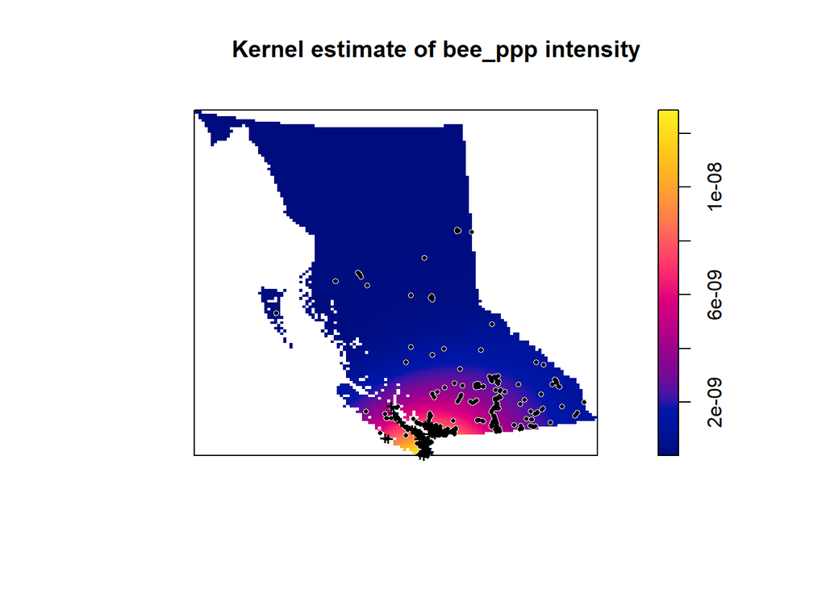

```r
library(spatstat.geom)
library(spatstat.explore)


lambda_u_hat <- density(bee_ppp)

plot(lambda_u_hat,
     main = "Kernel estimate of bee_ppp intensity")

plot(bee_ppp,
     pch = 16,
     cex = 0.6,
     cols = "white",
     add = TRUE)
plot(bee_ppp,
     pch = 16,
     cex = 0.5,
     cols = "black",
     add = TRUE)
```

The kernel density estimate of bee_ppp shows that bee observations are strongly clustered in the southern part of the study area. The intensity surface highlights areas with the highest densities in yellow, suggesting these are potential hotspots for bee activity or observation effort. The presence of many zero- or low-intensity zones in the north may indicate ecological constraints, lower sampling effort, or habitat unsuitability.

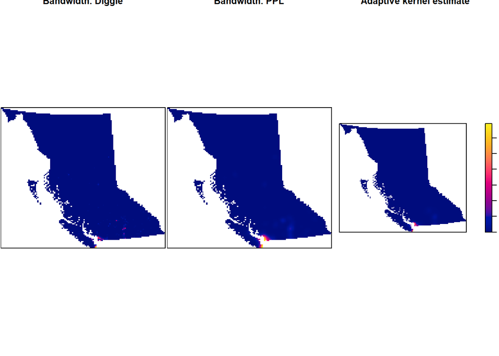

```r
library(spatstat.geom)
library(spatstat.explore)

par(mfrow = c(1, 3), mar = rep(0.1, 4))

# 1. Diggle bandwidth
plot(density(bee_ppp, sigma = bw.diggle(bee_ppp)),
     ribbon = FALSE,
     main = "Bandwidth: Diggle")

# 2. PPL bandwidth
plot(density(bee_ppp, sigma = bw.ppl(bee_ppp)),
     ribbon = FALSE,
     main = "Bandwidth: PPL")

# 3. Adaptive KDE
lambda_u_hat_adaptive <- adaptive.density(bee_ppp, method = "kernel")
plot(lambda_u_hat_adaptive,
     main = "Adaptive kernel estimate")
```

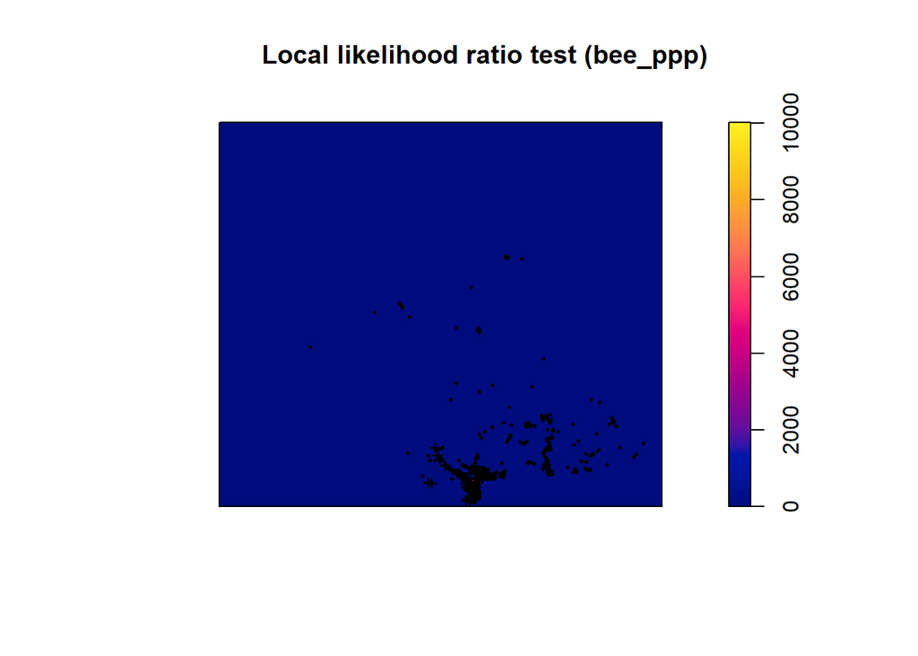

```r
library(spatstat.explore)

R <- bw.ppl(bee_ppp)

LR <- scanLRTS(bee_ppp, r = R)

plot(LR, main = "Local likelihood ratio test (bee_ppp)")

contour(LR, add = TRUE)
plot(bee_ppp, add = TRUE, pch = 16, cex = 0.4, cols = "black")
```

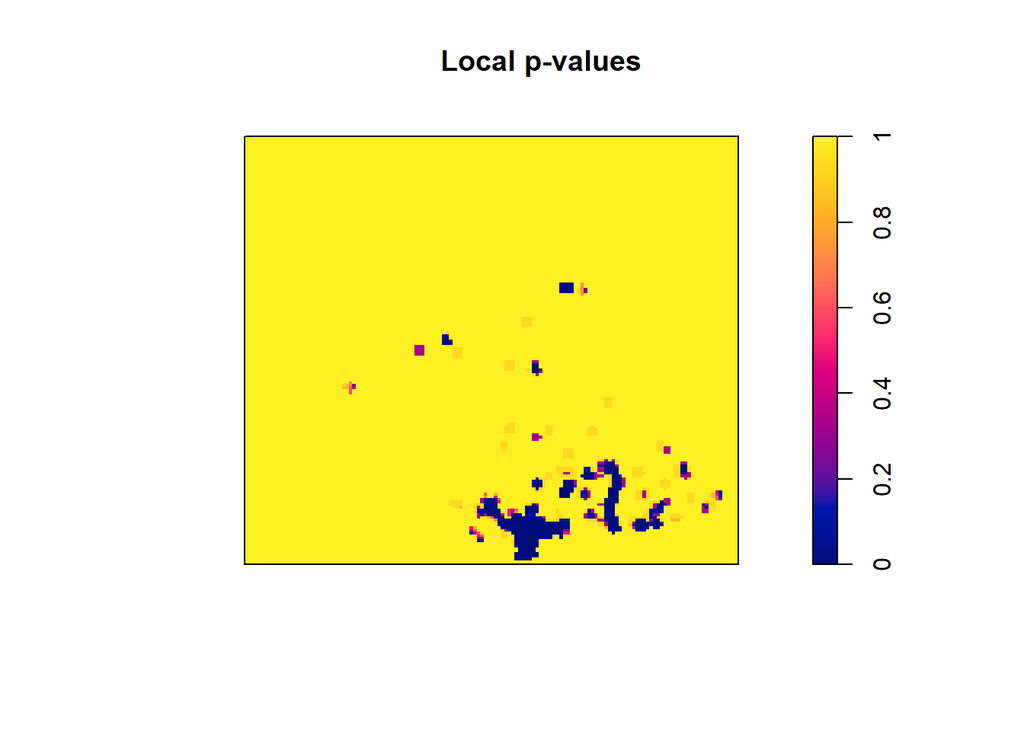

```r
pvals <- eval.im(pchisq(LR,
                        df = 1,
                        lower.tail = FALSE))
plot(pvals, main = "Local p-values")
```

```r
bee_elev <- DATA$Elevation
elev <- bee_elev

b <- quantile(elev, probs = (0:4)/4, type = 2)
Zcut <- cut(elev, breaks = b)
V <- tess(image = Zcut)

quadratcount(bee_ppp, tess = V)
```

```
## tile
##          (-130,761]       (761,1.1e+03]  (1.1e+03,1.46e+03] (1.46e+03,3.55e+03]
##                1040                  54                   9                   8
```

```r
rho <- rhohat(bee_ppp, elev)
```

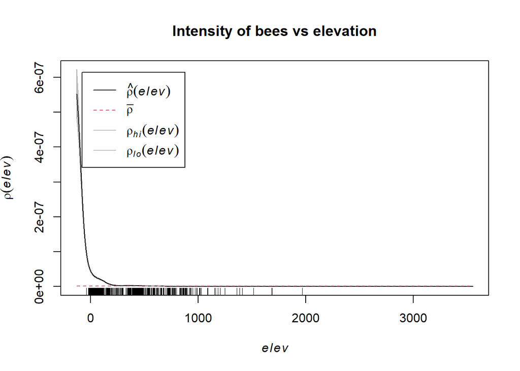

```r
plot(rho, main = "Intensity of bees vs elevation")
```

```r
library(spatstat.explore)

env <- envelope(bee_ppp, Gest, nsim = 39)
```

```
## Generating 39 simulations of CSR  ...
## 1, 2, 3, 4, 5, 6, 7, 8, 9, 10, 11, 12, 13, 14, 15, 16, 17, 18, 19, 20,
## 21, 22, 23, 24, 25, 26, 27, 28, 29, 30, 31, 32, 33, 34, 35, 36, 37, 38,
## 39.
##
## Done.
```

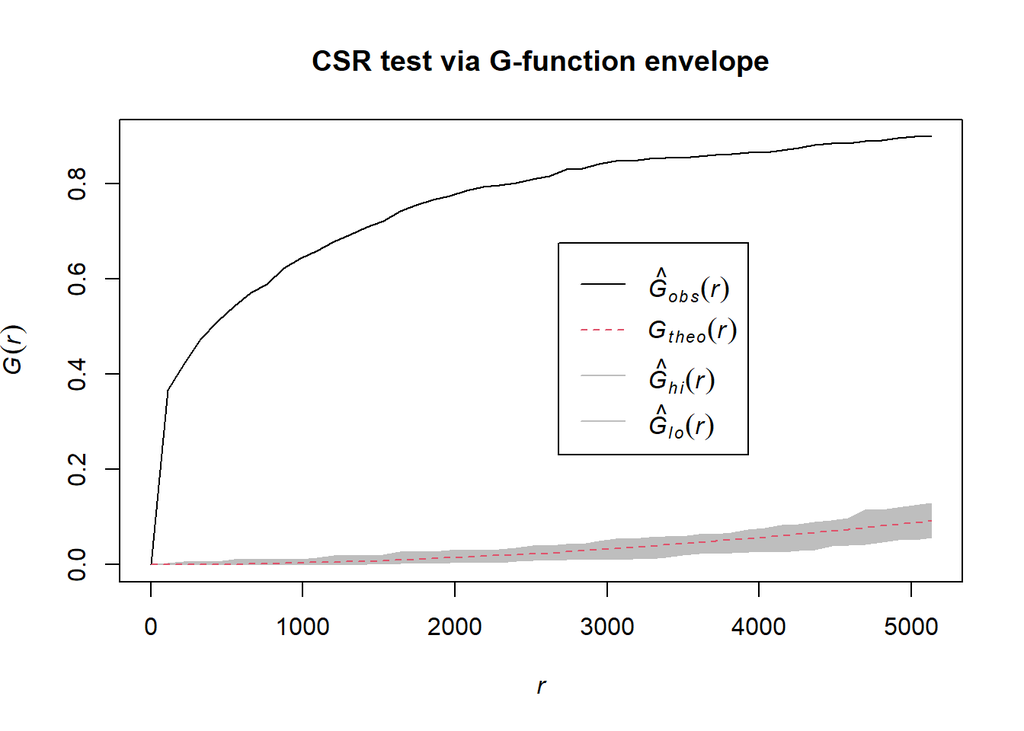

```r
plot(env, main = "CSR test via G-function envelope")
```

A spatial point pattern analysis was conducted to assess the relationship between bee intensity and elevation, as well as deviations from complete spatial randomness (CSR). The non-parametric estimate showed that bee intensity is strongly concentrated at lower elevations. A Monte Carlo envelope test using the G-function further revealed that the observed bee locations exhibit significant clustering, with the observed G-function lying well above the simulated CSR envelopes.